# 데이터 분석 보고서 만들기

이보라

2020-09-01

## R markdown

마크다운 문법으로 코드를 작성해 HTML로 변환할 수 있다. R markdown을 이용하면 분석 과정과 결과를 자세하게 기술할 수 있어 **재현 가능성**을 갖춘 *데이터 분석 보고서*를 만들 수 있다.

## 분석 결과

#### 분석 1

`moonBook` 패키지의 acs 데이터를 이용하여 아래와 같이 작성하면 코드를 실행한 결과물이 출력된다.

```r
library(moonBook)
mytable(acs)
```

```
##
##          Descriptive Statistics
## ----------------------------------------
##                         N      Total
## ----------------------------------------
##  age                  857  63.3 ± 11.7
##  sex                  857
##    - Female                287  (33.5%)
##    - Male                  570  (66.5%)
##  cardiogenicShock     857
##    - No                    805  (93.9%)
##    - Yes                     52  (6.1%)
##  entry                857
##    - Femoral               312  (36.4%)
##    - Radial                545  (63.6%)
##  Dx                   857
##    - NSTEMI                153  (17.9%)
##    - STEMI                 304  (35.5%)
##    - Unstable Angina       400  (46.7%)
##  EF                   723   55.8 ± 9.6
##  height               764  163.2 ± 9.1
##  weight               766  64.8 ± 11.4
##  BMI                  764   24.3 ± 3.3
##  obesity              857
##    - No                    567  (66.2%)
##    - Yes                   290  (33.8%)
##  TC                   834 185.2 ± 47.8
##  LDLC                 833 116.6 ± 41.1
##  HDLC                 834  38.2 ± 11.1
##  TG                   842 125.2 ± 90.9
##  DM                   857
##    - No                    553  (64.5%)
##    - Yes                   304  (35.5%)
##  HBP                  857
##    - No                    356  (41.5%)
##    - Yes                   501  (58.5%)
##  smoking              857
##    - Ex-smoker             204  (23.8%)
##    - Never                 332  (38.7%)
##    - Smoker                321  (37.5%)
## ----------------------------------------
```

- 데이터는 총 857의 개체와 17의 변수로 이루어져 있다.
- 이들의 평균 연령은 63.3115519이다.
- 이중 남자는 570명, 여자는 287명이다.

#### 분석 2

아래와 같이 작성하면 acs 데이터에서 당뇨(DM)에 따른 BMI(BMI)의 boxplot을 출력하고, 이들에 대한 t-test를 수행할 수 있다.

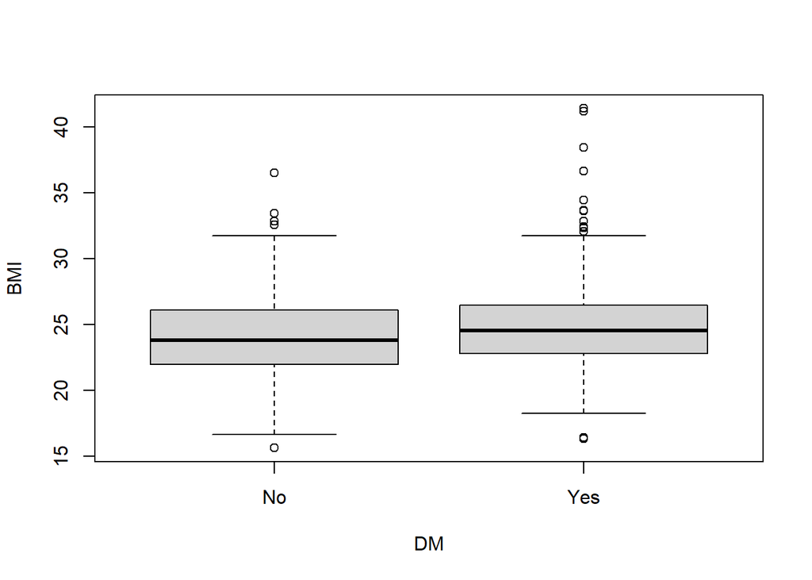

```r
boxplot(BMI ~ DM, data=acs)
```

```r
test <- t.test(BMI ~ DM, data=acs)
test
```

```
##
##  Welch Two Sample t-test
##
## data:  BMI by DM
## t = -3.3221, df = 484.24, p-value = 0.0009611
## alternative hypothesis: true difference in means is not equal to 0
## 95 percent confidence interval:
##  -1.3938684 -0.3578144
## sample estimates:
##  mean in group No mean in group Yes
##          23.97008          24.84592
```

1. 당뇨(DM=Yes)인 군의 경우 BMI의 평균은 24.8459237임
2. 정상(DM=No)인 군의 경우 BMI의 평균은 23.9700823임
3. 두 군은 유의한 차이가 난다

## 그림 삽입

1. moonBook 패키지를 만든 분은 카톨릭대학교병원의 문건웅교수님이시다.

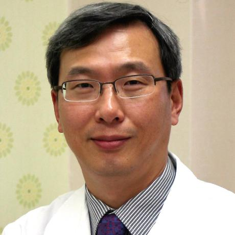

2. moonBook 패키지에 대한 설명서는 https://cran.r-project.org/web/packages/moonBook/moonBook.pdf에서 다운 가능하다